# Business Statistics Mid-Term Assessment IB94X0 2022-2023 #1

5583665

```r
library(tidyverse)
library(ggplot2)
library(emmeans)
library(gridExtra)
options(width=100)
```

# Dictionary

The below is a dictionary table that contains explanation for all data types used

[output not shown]

# Section 1

## Data - Children in low income homes per ward across all years

```r
#Pulling data

Data.x <- read_csv('children_low_income_data.csv')
#check for N/As - 33 were found

N.A_Check <- sum(is.na(Data.x))

Data <- Data.x %>% na.omit

# Data regarding number of children in low income homes per borough across all years

House.Data <- Data %>% group_by(`Borough`) %>% summarise(
  Average = mean(children),
  Standard_deviation = sd(children),
  "Lowest number of children in low income homes" = min(children),
  "Highest number of children in low income homes" = max(children))


House.Data
```

```
## # A tibble: 33 × 5
##    Borough              Average Standard_deviation Lowest number of childre…¹ Highest number of ch…²
##    <chr>                  <dbl>              <dbl>                      <dbl>                  <dbl>
##  1 Barking and Dagenham   987.               259.                         551                   1750
##  2 Barnet                 588.               340.                         116                   1807
##  3 Bexley                 506.               246.                         174                   1469
##  4 Brent                  708.               281.                         249                   1578
##  5 Bromley                390.               211.                         113                   1062
##  6 Camden                 452.               268.                          78                   1373
##  7 City of London          26.5               31.8                          5                    156
##  8 Croydon                570.               315.                          48                   1508
##  9 Ealing                 640.               314.                         128                   1327
## 10 Enfield                738.               409.                         193                   1895
## # ℹ 23 more rows
## # ℹ abbreviated names: ¹`Lowest number of children in low income homes`,
## #   ²`Highest number of children in low income homes`
```

## Exclude unusual boroughs

```r
#data filtered out

Filtered_Data<- filter(Data, !(Borough%in%c('City of London', 'Kensington and Chelsea','Kingston upon Thames', 'Richmond upon Thames', 'Westminster')))

summary(Filtered_Data)
```

```
##   Ward code         Wards (2018)         Borough               year         children
##  Length:4480        Length:4480        Length:4480        Min.   :2014   Min.   :  38.0
##  Class :character   Class :character   Class :character   1st Qu.:2016   1st Qu.: 330.0
##  Mode  :character   Mode  :character   Mode  :character   Median :2018   Median : 569.0
##                                                           Mean   :2018   Mean   : 621.1
##                                                           3rd Qu.:2019   3rd Qu.: 836.0
##                                                           Max.   :2021   Max.   :2094.0
```

## Visualise data for different years

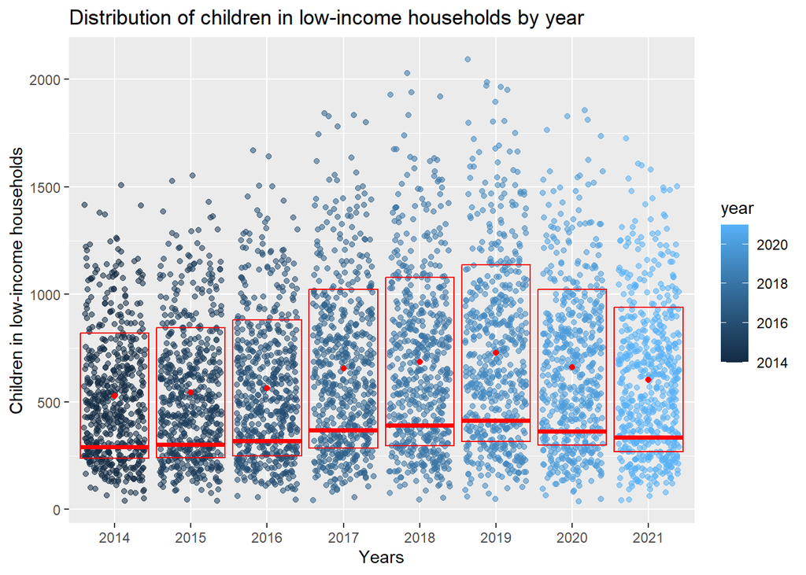

```r
# Visualisation that shows the distribution of children in low income households in wards for each year with representation of the mean value and standard deviation for each year.

# first created the mean and standard deviation data

Data.Mean_Sd <- Filtered_Data %>% group_by(year) %>% summarise(Mean = mean(children), Standard_deviation = sd(children))

# Identified Max and Min for standard deviation upper and lower bounds

ymin.<- Data.Mean_Sd$Mean  - Data.Mean_Sd$Standard_deviation
ymax.<- Data.Mean_Sd$Mean  + Data.Mean_Sd$Standard_deviation

#Plot graph

Data.graph <- ggplot() +
  geom_jitter(data = Filtered_Data, mapping=aes(x= factor(year) , y= children, alpha=0.5, colour = year))+
  geom_point(mapping=aes(x= factor(Data.Mean_Sd$year), y= Data.Mean_Sd$Mean ), color= "red") +
  geom_crossbar(aes(x= factor(Data.Mean_Sd$year), y = Data.Mean_Sd$Standard_deviation, ymin=ymin., ymax=ymax.), col='red')+
  labs(x="Years", y="Children in low-income households", title ="Distribution of children in low-income households by year") + scale_alpha(guide = 'none')

Data.graph
```

## T.test and Estimation - using Null Hypothesis Significance Testing, and the Estimation approach

```r
#T.test

Y.2014 <- Filtered_Data %>% filter(year == 2014)

Y.2021 <- Filtered_Data %>% filter(year == 2021)

t.test(Y.2021$children, Y.2014$children)
```

```
##
##  Welch Two Sample t-test
##
## data:  Y.2021$children and Y.2014$children
## t = 4.0215, df = 1095.2, p-value = 6.18e-05
## alternative hypothesis: true difference in means is not equal to 0
## 95 percent confidence interval:
##   38.6873 112.4091
## sample estimates:
## mean of x mean of y
##  603.8696  528.3214
```

```r
#Estimation

Year14x21.data <- Filtered_Data %>% filter(year %in% c(2021,2014))

m.Year14x21 <- lm(children~year, data=Year14x21.data)

( m.Year14x21_emm <- emmeans(m.Year14x21, ~ year))
```

```
##  year emmean   SE   df lower.CL upper.CL
##  2014    528 13.3 1118      502      554
##  2021    604 13.3 1118      578      630
##
## Confidence level used: 0.95
```

```r
( m.Year14x21.contrast <- confint(pairs(m.Year14x21_emm, reverse = TRUE)) )
```

```
##  contrast            estimate   SE   df lower.CL upper.CL
##  year2021 - year2014     75.5 18.8 1118     38.7      112
##
## Confidence level used: 0.95
```

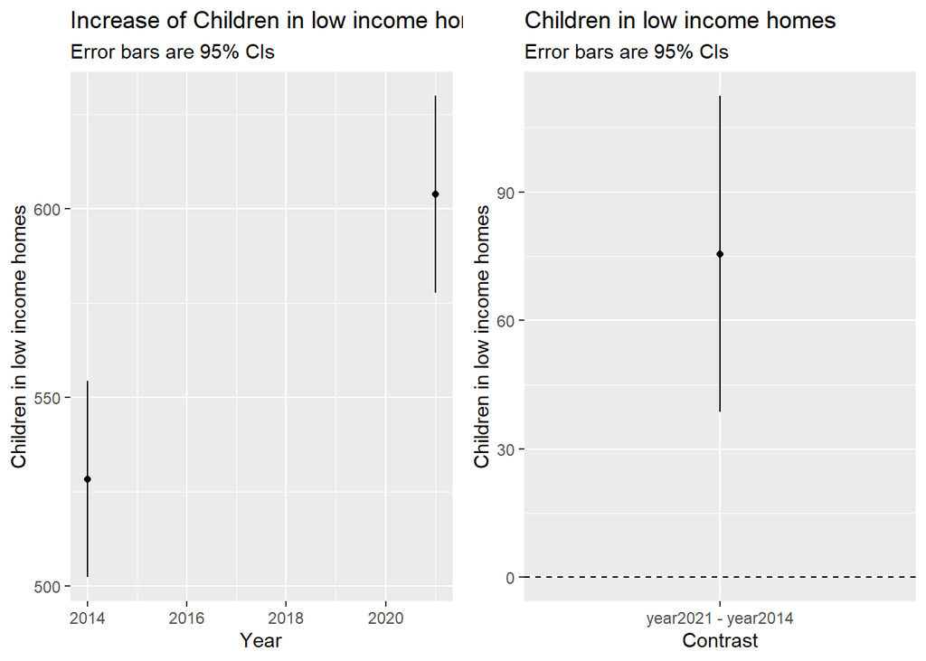

```r
# Graph

grid.arrange(
    ggplot(summary(m.Year14x21_emm), aes(x= year, y=emmean, ymin=lower.CL, ymax=upper.CL)) +
        geom_point() + geom_linerange() +
        labs(y="Children in low income homes", x="Year", subtitle="Error bars are 95% CIs", title="Increase of Children in low income homes"),
    ggplot(m.Year14x21.contrast, aes(x=contrast, y=estimate, ymin=lower.CL, ymax=upper.CL)) +
        geom_point() + geom_linerange() +
        labs(y="Children in low income homes", x="Contrast", subtitle="Error bars are 95% CIs", title="Children in low income homes") +
        geom_hline(yintercept=0, lty=2),
    ncol=2
)
```

# Section 2

### Introduction

This report will present findings by analysing data regarding children living in low-income households in London. We will be looking at data spanning across 8 years (from 2014 to 2021). The data consists of the counts for the number of children living in London’s boroughs respective sub-divided wards.

### Data - Children in low income homes per ward across all years

Identifying individual borough’s average, standard deviation, Lowest number of children in low income homes and Highest number of children in low income homes allows comparing data between boroughs and identifying key issues and trends.

Boroughs such as Barking & Dagenham (987), Newham (1213) and Tower Hamlets (1035) have the highest averages of children in low income homes with figures close to 1000 whereas in comparison City of London (26), Kensington and Chelsea (147), Richmond upon Thames (163) have the lowest averages out of the whole dataset.

These figures correlate well with the Highest (max) and lowest (min) number of children in low income homes. Data from City of London(156), Kensington and Chelsea (557), Richmond upon Thames (507) Highest number of children in low income homes have figures similar to Barking and Dagenham (551) and Tower Hamlets (218) lowest number of children in low income homes have figures.

However there are boroughs with large discrepancies between their Highest and Lowest children in low income homes, depicted through their standard deviation. For example Enfield’s standard deviation is 408 which is without fault representative as the borough’s lowest ranges from 193 where as their highest ranges to 1895.

### Exclude unusual boroughs

The boroughs excluded include City of London; Kensington and Chelsea; Kingston upon Thames; Richmond upon Thames; Westminster.

### Visualise data for different years

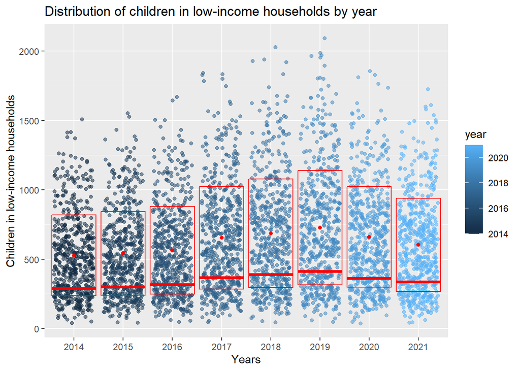

As can be seen from the graph above, the number of children in low-income homes saw a steady increase through years 2014 up until 2019 before starting a gradual decent till 2021.

The data points were initially concentrated closer to the mean (red dot) with lower levels of standard deviation as can be seen by the thick red line, overall proportions of the standard deviation box and maximum/minimum regions the box (maximum is the upper section and minimum is the lower section). It stays fairly concentrated and stable from 2014 to 2016 with similar data means (in the range of 528 to 565) and similar standard deviation (in the range of 291 to 317).

2017 is where the first noticeable discrepancy and higher dispersion of data is seen with mean surging to 655, standard deviation to 369 and standard deviation box proportions increasing due to maximum deviation increasing and minimum threshold rising.The dispersion can also be visibly see with outlier close to the 2000 mark. The rate of growth of the dependency continues till 2019 where the data reaches over all peak mean of 727 and standard deviation of 412 before seeing a decline from 2020 with the mean dropping to 660. The trend following through to 2021 at a mean of 604.

### T-test ( Null Hypothesis Significance Testing) - compare 2021 to 2014

The mean number of children in low-income homes per ward for 2021 was 604; where as the mean number of in children low-income homes per ward for 2014 was 528.

The results of the t-test reveal a statistically significant difference in the mean number of children in low-income households between 2014 and 2021, Welch t(1095)= 4.0215, p<.0001. Indicating a notable increase observed with a difference of 76 children between years 2021 compared to 2014.

### Estimation

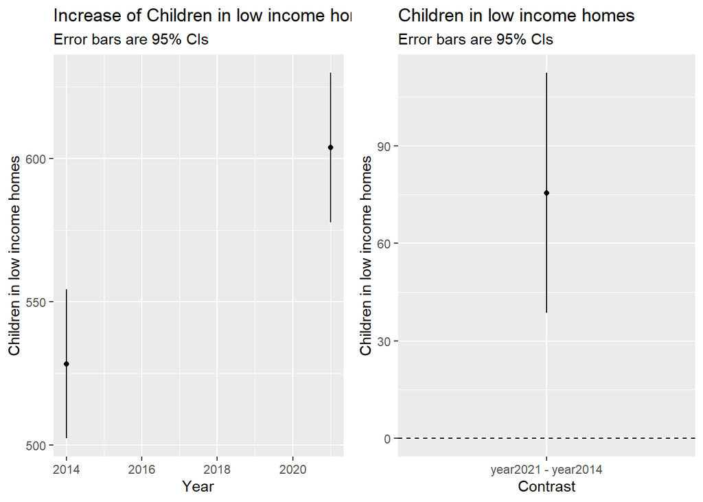

The mean number of children in low-income homes per ward for 2021 is 604, 95% CI [578–630]. The mean number of children in low-income homes per ward for 2014 95% CI [502–554]. A mean increase observed of 76 children 95% CI [38.7–112] lower in 2014 compared to 2021.